# Analisis exploratorio

Castro Jimenez

06/01/2023

```r
library(tidyverse)
library(readr)
library(skimr)
library(lubridate)
library(gghalves)
Rat_Sightings <- read_csv("Rat_Sightings.csv",na = c("", "NA", "N/A"))
```

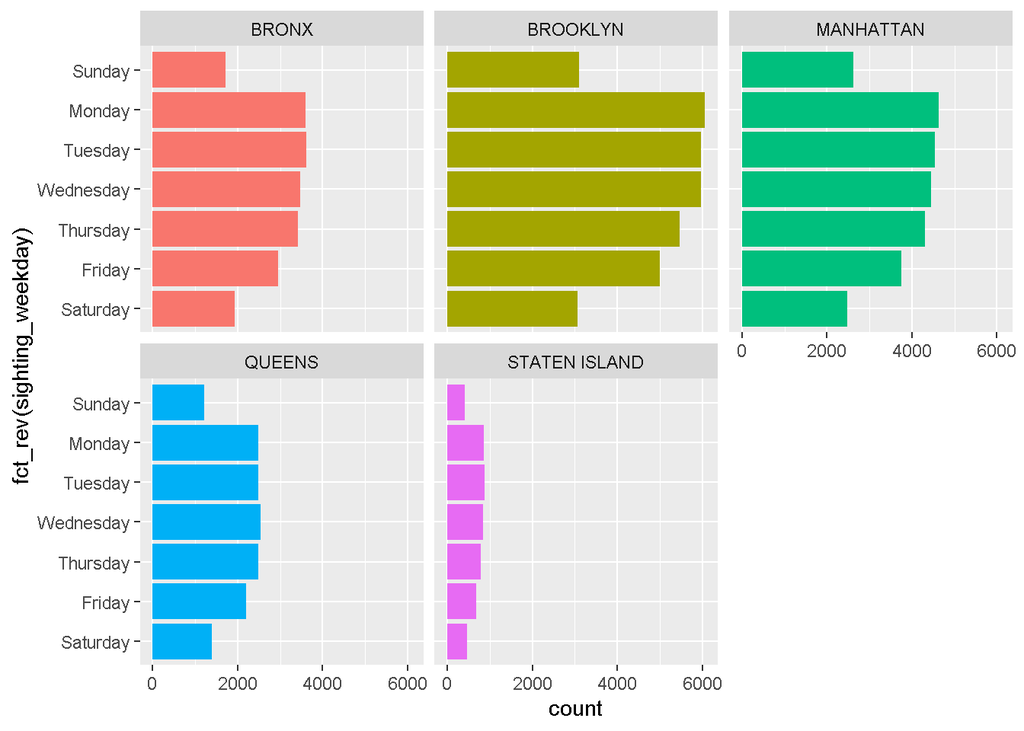

```r
Rat_Sightings<- Rat_Sightings %>% select(-("School or Citywide Complaint":"Ferry Terminal Name") )

rats_clean <- Rat_Sightings %>%
  rename(created_date = `Created Date`,
         location_type = `Location Type`,
         borough = Borough) %>%
  mutate(created_date = mdy_hms(created_date)) %>%
  mutate(sighting_year = year(created_date),
         sighting_month = month(created_date),
         sighting_day = day(created_date),
         sighting_weekday = wday(created_date, label = TRUE, abbr = FALSE)) %>%
  filter(borough != "Unspecified")

rats_clean %>%ggplot(mapping = aes(x=fct_rev(sighting_weekday),fill=borough ))+
  geom_bar()+facet_wrap(vars(borough))+guides(fill=FALSE)+coord_flip()
```

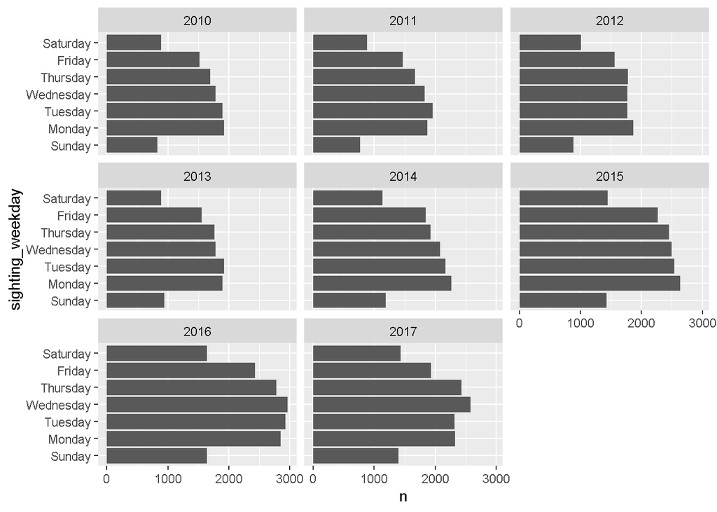

```r
# Assign a summarized data frame to an object to use it in a plot
rats_by_weekday <- rats_clean %>%
  count(sighting_weekday, sighting_year)

ggplot(data=rats_by_weekday,mapping = aes(x=sighting_weekday,y=n))+
  geom_col()+facet_wrap(vars(sighting_year))+coord_flip()
```

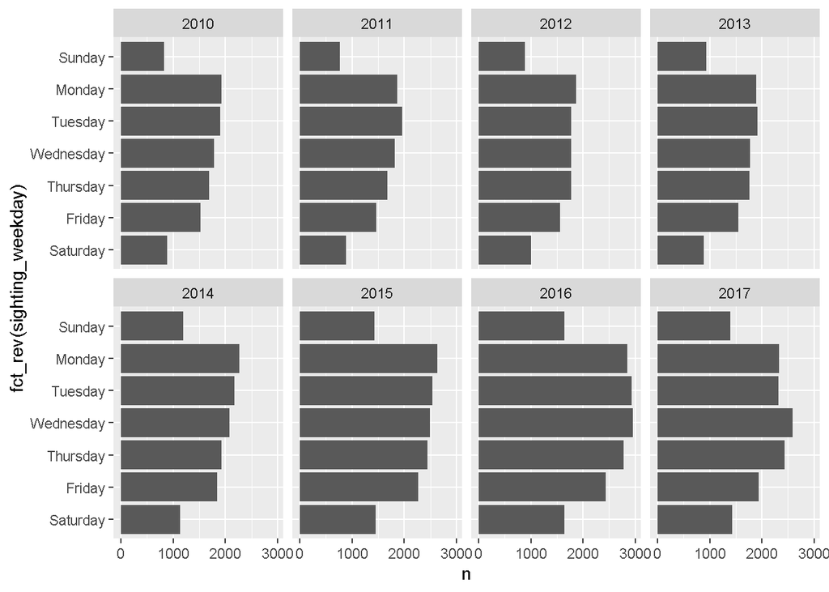

```r
ggplot(rats_by_weekday, aes(x = fct_rev(sighting_weekday), y = n)) +
  geom_col() +
  coord_flip() +
  facet_wrap(~ sighting_year,nrow = 2)
```

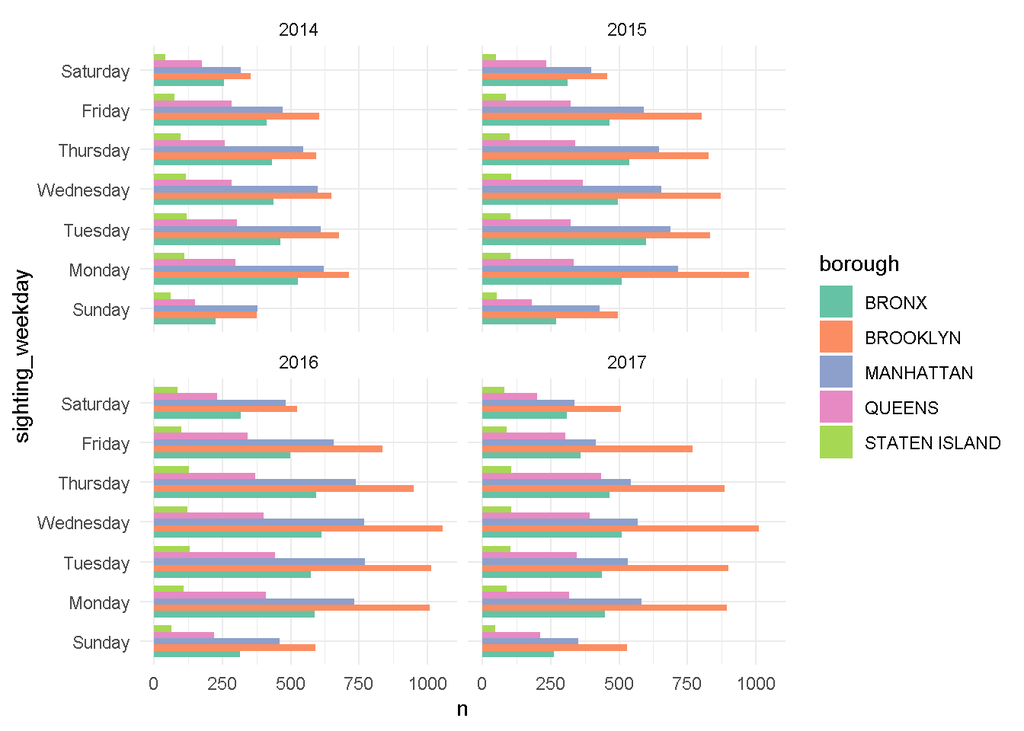

```r
# See the count of rat sightings by weekday and borough
rats_clean %>%
  count(sighting_weekday, borough, sighting_year) %>%
  filter(sighting_year>2013,sighting_year<2018) %>%
  ggplot(mapping = aes(x=sighting_weekday,y=n,fill=borough))+
  geom_col(position = "dodge",width = 0.8)+facet_wrap(vars(sighting_year))+
  scale_fill_brewer(palette = "Set2")+theme_minimal()+coord_flip()
```

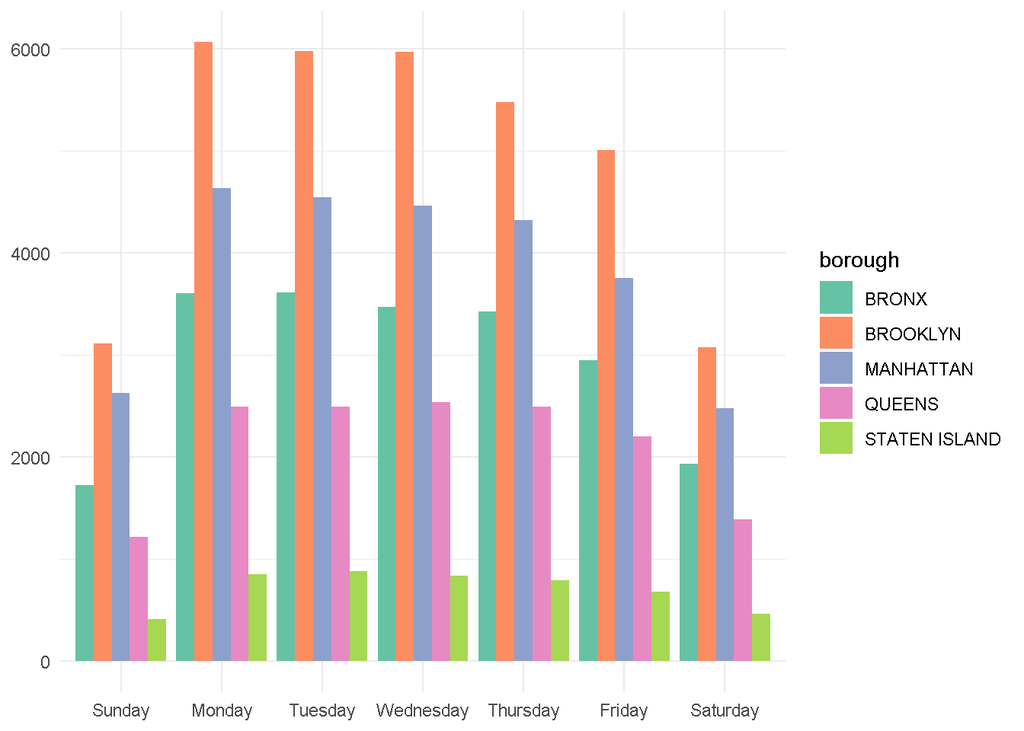

```r
# An alternative to count() is to specify the groups with group_by() and then
# be explicit about how you're summarizing the groups, such as calculating the
# mean, standard deviation, or number of observations (we do that here with
# `n()`).
rats_clean %>%
  group_by(sighting_weekday, borough) %>%mutate(borough=as.factor(borough)) %>%
  summarize(n = n()) %>%
  ggplot(mapping = aes(x=sighting_weekday,y=n,fill=borough))+
  geom_col(position = "dodge")+scale_fill_brewer(palette = "Set2")+theme_minimal()+
  xlab(label = NULL)+ylab(label = NULL)
```

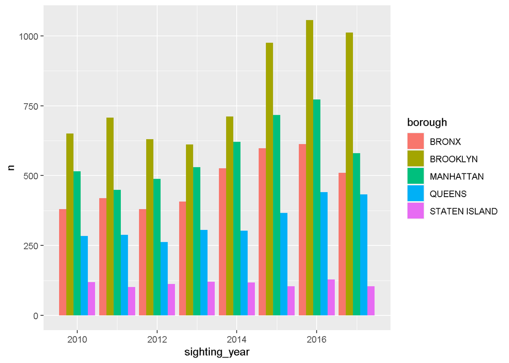

```r
rats_clean %>%
  count(sighting_weekday, borough, sighting_year) %>%
  ggplot(mapping = aes(x=sighting_year,y=n,fill=borough))+
  geom_col(position = "dodge")
```

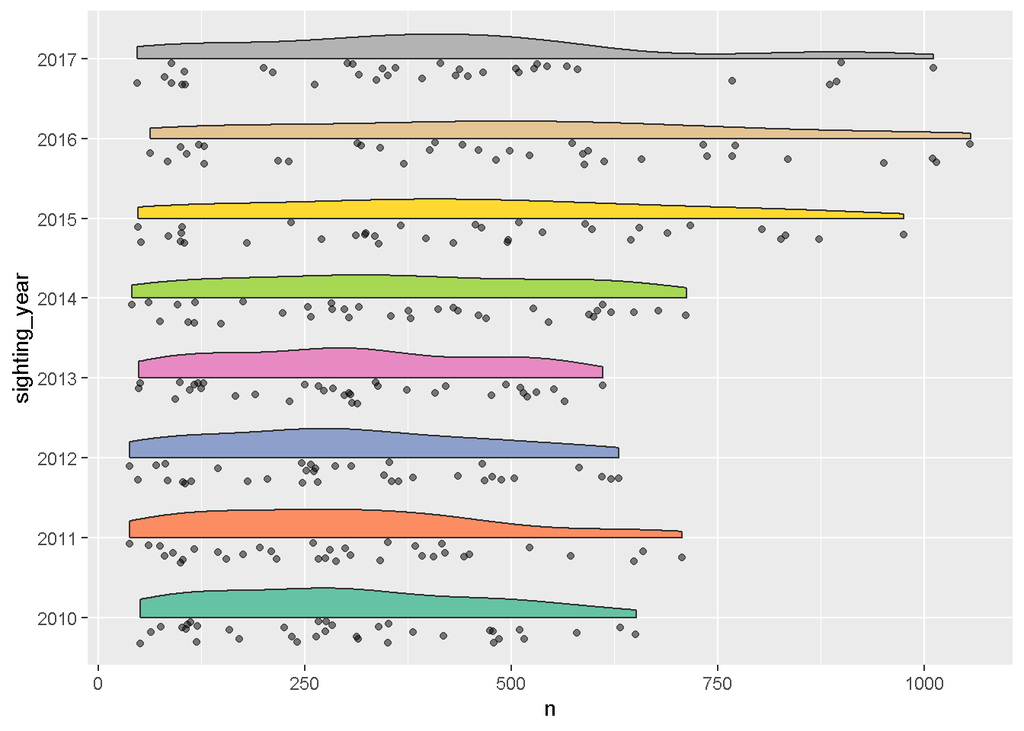

```r
rats_clean %>%
  count(sighting_weekday, borough, sighting_year) %>%
  mutate(sighting_year=as.factor(sighting_year)) %>%
  ggplot(mapping = aes(x=sighting_year,y=n,fill=sighting_year))+
  geom_half_point(aes(),alpha=0.5, side = "l",) +
  geom_half_violin(aes(), side = "r") +coord_flip()+guides(fill=FALSE)+
  scale_fill_brewer(palette = "Set2")
```

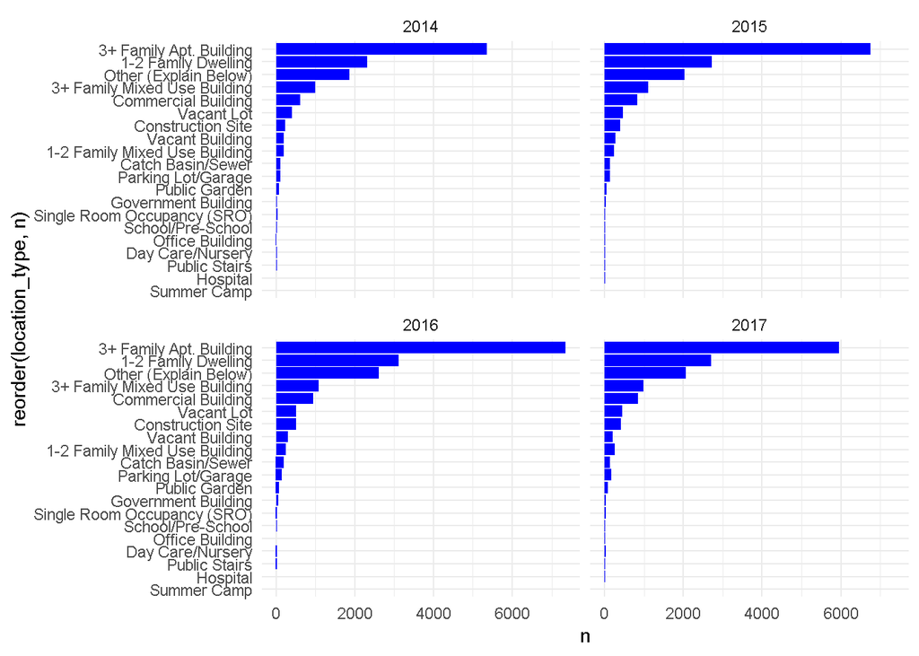

```r
type_vi <- rats_clean %>%
  count(location_type,Status,sighting_year) %>%
  mutate(Status=as.factor(Status),location_type=as.factor(location_type)) %>%
  filter(!is.na(location_type)) %>%
  filter(sighting_year>2013,sighting_year<2018)

type_vi %>%
  ggplot(mapping = aes(x = reorder(location_type,n),y=n) )+
  geom_col(fill="blue")+coord_flip()+facet_wrap(vars(sighting_year))+theme_minimal()
```

¿Qué tenía de malo el gráfico original (si estás arreglando una de las figuras originales)?

¿Qué historia estás contando con tu nuevo gráfico?

en los dos primeros graficos podemos observar que los avistamiento de ratones son mas concurridos en Brooklyn y menos concurrido en State Island tambien podemos ver que los dia de la semana son los dias preferidos por los ratones y en efecto los fines de semana son menos visto los ratones una hipotesis seria por la mayor presencia humana en las calle en los fines de semanas. tambien vemos un aumento de ratones apartir del año 2013 siendo el año 2016 el año con mayor presencia de ratones y en Brooklyn con el record de presencia de ratones en el 2016

¿Cómo aplicaste los principios de CRAP?

se aplico el principio del contrastes unos buenos colores para resaltar la informacion relevante se utilizo un fondo que no llame mucho la atencion tambien aplicamos la repeticion con varias graficas por defecto los graficos ya vienen alineados y el principio de agrupacion con los diagrama de barras juntos con su respectivo dia de la semana.